# Base rates for lab accidents causing pandemics

Joshua Blake

2023-09-15

```r
library(broom)
library(dplyr)
library(ggplot2)
library(purrr)
library(tidyr)
```

# Summary

- I aim to estimate the base rate of lab accidents causing pandemics. By lab accidents, I mean any pandemic that was not intentional but would not have occurred without human intervention in a research setting. That could include virus hunting, gain-of-function research, or other experiments. Pandemics are defined as killing at least 1 in 100,000 of the global population, around 80,000 deaths (this is the threshold from Marani et al. 2021).
- I use three proxies for the amount of risky research being conducted: the number of BSL-4 labs, the number of lab accidents, and the number of virology papers published. Note that I am not attempting to quantify the actual number of lab-years contributing. These have all been growing at the same exponential rate over the past few decades, meaning that they agree on the amount of risk.
- There have been 1 lab-leak pandemics to date: the 1977 Russian flu pandemic. COVID-19’s origin is debated, and I present either scenario. I make no attempt or provide judgment on COVID-19’s origin.
- I estimate that we should expect 1 or 2 pandemics in the next decade, with around a 60% chance that at least 1 occurs. For context, the historical record suggests, in expectation, 2.5 zoonotic pandemics over the next decade.
- I am 80% confident that this is an overestimate for the following reasons.
  - The Russian flu pandemic was caused by labs with much less safety than modern ones.
  - COVID-19, if it were a lab-leak, was downstream of the PREDICT virus hunting effort. The only comparable successor programme, DEEP VZN, has been canceled.
  - The number of virology papers being published has been declining since the second half of the 2000s, which is not included in my extrapolation of growth rates. This could indicate that less risky research is being conducted than my extrapolation suggests.
- The main reason to think this is an underestimate is that technological advances could accelerate the rate of risky research. For example, if experimentation with viruses that could infect humans was being performed by biohackers outside of formal laboratories. This could lead to a discontinuous increase in the rate of risky research, or an increase that is not captured well by the proxies I have used.

# Methods

To estimate the base rate, we need two quantities. First, the number of pandemics that lab accidents have caused. This can be easily found by looking at the historic record. Second, a measure of the amount of lab experiments that could cause such a pandemic; I refer to this as “risky research units”. I then extrapolate research units into the future to forecast a base rate for lab accidents causing pandemics.

No good data exists on risky research units directly. However, by applying a continuous time [Gamma-Poisson model](https://joshuablake.co.uk/blog/gamma-poisson/) we only need a measure that is proportional to the number of experiments.

# Measuring risky research units

I consider three proxies for the number of risky research units being conducted. First, the number of BSL-4 labs ([GlobalBioLabs 2023](https://static1.squarespace.com/static/62fa334a3a6fe8320f5dcf7e/t/6412d3120ee69a4f4efbec1f/1678955285754/KCL0680_BioLabs+Report_Digital.pdf)). I transform this into the net increase in labs per year to reduce autocorrelation. Second, the number of known lab accidents as reported by [Manheim and Lewis 2022](https://f1000research.com/articles/10-752). Third, the number of virology papers published per year according to Web of Science (downloaded from their website). These appear to be growing at roughly the same rate, as seen by fitting either separate or joint Poisson regressions to the datasets.

```r
incident_counts = readr::read_csv(here::here("2023-08_lab-leaks/lab-accidents.csv"), show_col_types = FALSE) |>
    filter(!is.na(Year))  |> # Extra rows added when copying from web
    mutate(
        year = case_match(
            Year,
            "Late 1970s" ~ 1977,
            .default = suppressWarnings(as.integer(stringr::str_sub(Year, end = 4)))
        )
    ) |>
    assertr::assert(assertr::not_na, year) |>
    count(year) |>
    complete(
        year = 1975:2016,
        fill = list(n = 0)
    ) |>
    mutate(type = "Lab accidents")

lab_counts = readr::read_csv(here::here("2023-08_lab-leaks/bsl4.csv"), show_col_types = FALSE) |>
    group_by(year = floor(year)) |>
    summarise(labs = floor(min(labs))) |>
    transmute(
        year,
        `New BSL4 labs` = labs - lag(labs),
    ) |>
    pivot_longer(-year, names_to = "type", values_to = "n") |>
    filter(!is.na(n))
web_of_science_counts = readr::read_tsv(here::here("2023-08_lab-leaks/web-of-science.tsv")) |>
    rename(year = `Publication Years`, n = `Record Count`) |>
    complete(
        year = 1953:2022,
        fill = list(n = 0)
    ) |>
    select(year, n) |>
    filter(year <= 2022) |>
    mutate(type = "Web of Science articles")
```

```r
all_counts = bind_rows(
    incident_counts,
    lab_counts,
    web_of_science_counts,
)

fit_counts = bind_rows(
    incident_counts,
    lab_counts,
    web_of_science_counts |> filter(year <= 2010),
)

tbl_models = fit_counts |>
    nest(data = !type) |>
    mutate(
        fit = map(data, ~glm(n ~ year, data = .x, family = "poisson")),
    ) |>
    add_row(
        type = "Joint",
        fit = list(glm(n ~ year + type, data = fit_counts, family = "poisson")),
    ) |>
    mutate(
        fit_aug = map(fit, broom::augment, se_fit = TRUE),
        fit_tidy = map(fit, broom::tidy, conf.int = TRUE),
    ) |>
    rename(model_type = type)
final_growth_rate = tbl_models |>
    unnest(fit_tidy) |>
    filter(term == "year", model_type == "Joint") |>
    assertr::verify(length(estimate) == 1) |>
    pull(estimate)
```

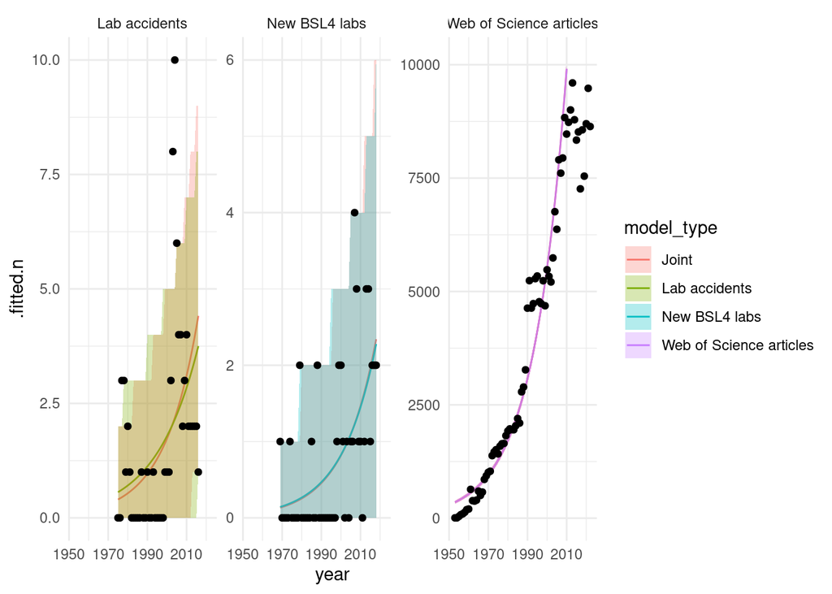

Poisson regression from fitting to each time series either individually or jointly (jointly assumes the same growth rate).

```r
tbl_models |>
    unnest(fit_aug) |>
    mutate(
        type = if_else(is.na(type), model_type, type),
        .fitted.n = exp(.fitted),
        ymin = qpois(0.025, exp(.fitted)),
        ymax = qpois(0.975, exp(.fitted)),
    ) |>
    # mutate(across(c(ymin, ymax, n, .fitted.n), ~.x / max(n)), .by = type) |>
    ggplot(aes(year, .fitted.n)) +
    geom_line(aes(color = model_type)) +
    geom_ribbon(
        aes(year, ymin = ymin, ymax = ymax, fill = model_type),
        alpha = 0.3,
    ) +
    geom_point(aes(year, n), data = all_counts) +
    facet_wrap(~type, scales = "free_y") +
    theme_minimal()
```

```r
fit_wos = glm(n ~ year, data = filter(web_of_science_counts, year <= 2010), family = "poisson")
augment(fit_wos, type.predict = "response", newdata = web_of_science_counts) |>
    ggplot(aes(year, .fitted)) +
    geom_line() +
    geom_point(aes(year, n)) +
    geom_ribbon(
        aes(year, ymin = qpois(0.025, .fitted), ymax = qpois(0.975, .fitted)),
        alpha = 0.3,
    ) +
    theme_minimal() +
    labs(
        x = "Year",
        y = "Number of papers published"
    )
```

[output not shown]

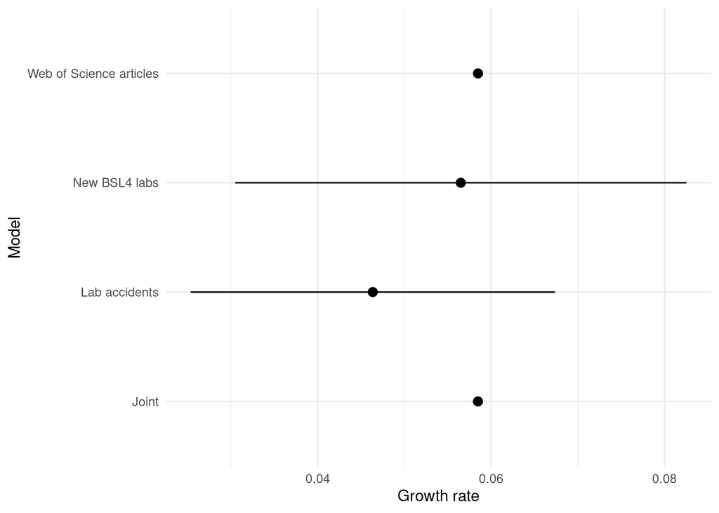

Growth rates from fitting to each time series either individually or jointly.

```r
tbl_models |>
    unnest(fit_tidy) |>
    filter(term == "year") |>
    ggplot(aes(estimate, model_type, xmin = estimate - 1.96 * std.error, xmax = estimate + 1.96 * std.error)) +
    geom_pointrange() +
    theme_minimal() +
    labs(
        x = "Growth rate",
        y = "Model"
    )
```

# Forecast

One lab risk pandemic has occurred to date: the 1977 Russian flu pandemic. COVID-19’s origin is debated, and I present either scenario.

The forecast will be based on three quantities. These can be calculated from the historic record, and the growth rate of risky research units $r$ estimated above.

- The number of risky research units conducted up until the time used for calculating the base rate, $t_b$. We will normalize this to 1, meaning that we define the number of units as $u(t) = r \exp(r(t-t_b))$. This gives the total risky research units conducted up until $t_b$ as $\int_{-\infty}^{t_b} u(t) dt = \exp(0) - \exp(-\infty) = 1$.
- The number of risky research units conducted in the period we are predicting, from $t_0$ for $d$ years. This is $u_p = \int_{t_0}^{t_0+d} u(t) dt = \exp(r(t_0+d-t_b)) - \exp(r(t_0-t_b)) = \exp(r(t_0-t_b)) (\exp(rd) - 1)$.
- The number of lab-leak pandemics that have occurred in the period used for calculating the base rate.

The estimate for the expected number of lab-leak pandemics per risky research unit (using a Gamma(1/3, 1/3) prior) is Gamma(a+1/3, 1). The expected number of lab-leak pandemics over the period of interest is $u_p(a + 1/3)$. The probability of there being at least one pandemic is $1 - 1 / (1 + u_p)^(a + 1/3)$.

This gives the following results, with r = 0.0584812

```r
r = final_growth_rate
leak_risks = tribble(
    ~Scenario, ~a, ~tb,
    "No pandemics", 0, 2022,
    "Pre-COVID", 1, 2019,
    "COVID zoonotic", 1, 2022,
    "COVID lab-leak", 2, 2022,
) |>
    mutate(
        t0 = 2024,
        d = 10,
        up = exp(r * (t0 - tb)) * (expm1(r * d)),
        E_lab_leaks = up * (a + 1/3),
        p_gte1_lab_leaks = 1 - 1 / (1 + up) ^ (a + 1/3),
    )
leak_risks
```

```
## # A tibble: 4 × 8
##   Scenario           a    tb    t0     d    up E_lab_leaks p_gte1_lab_leaks
##   <chr>          <dbl> <dbl> <dbl> <dbl> <dbl>       <dbl>            <dbl>
## 1 No pandemics       0  2022  2024    10 0.893       0.298            0.192
## 2 Pre-COVID          1  2019  2024    10 1.06        1.42             0.620
## 3 COVID zoonotic     1  2022  2024    10 0.893       1.19             0.573
## 4 COVID lab-leak     2  2022  2024    10 0.893       2.08             0.774
```

For comparison, Marani et al. (2021) suggests 2.5 zoonotic pandemics per decade, although this rate may have decreased since World War II.

Below I show how the rate is changing over time due to the change in risky research units.

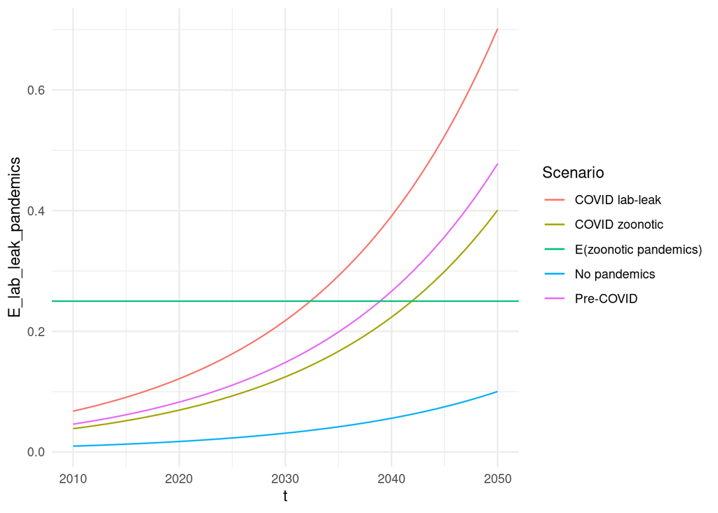

```r
leak_risks |>
    cross_join(tibble(t = 2010:2050)) |>
    mutate(
        E_lab_leak_pandemics = r * exp(r * (t - tb)) * (a + 1/3),
    ) |>
    ggplot(aes(t, E_lab_leak_pandemics, color = Scenario)) +
    geom_line() +
    geom_hline(aes(colour = "E(zoonotic pandemics)", yintercept = 0.25)) +
    theme_minimal()
```

# Discussion and conclusion

# Breakpoint analysis

The plots above suggest the rate of growth is changing. Here, I allow two breakpoints in the rate. A more parsimonious model would be a sigmoid, but I failed to fit one to the data…

```r
library(segmented)
```

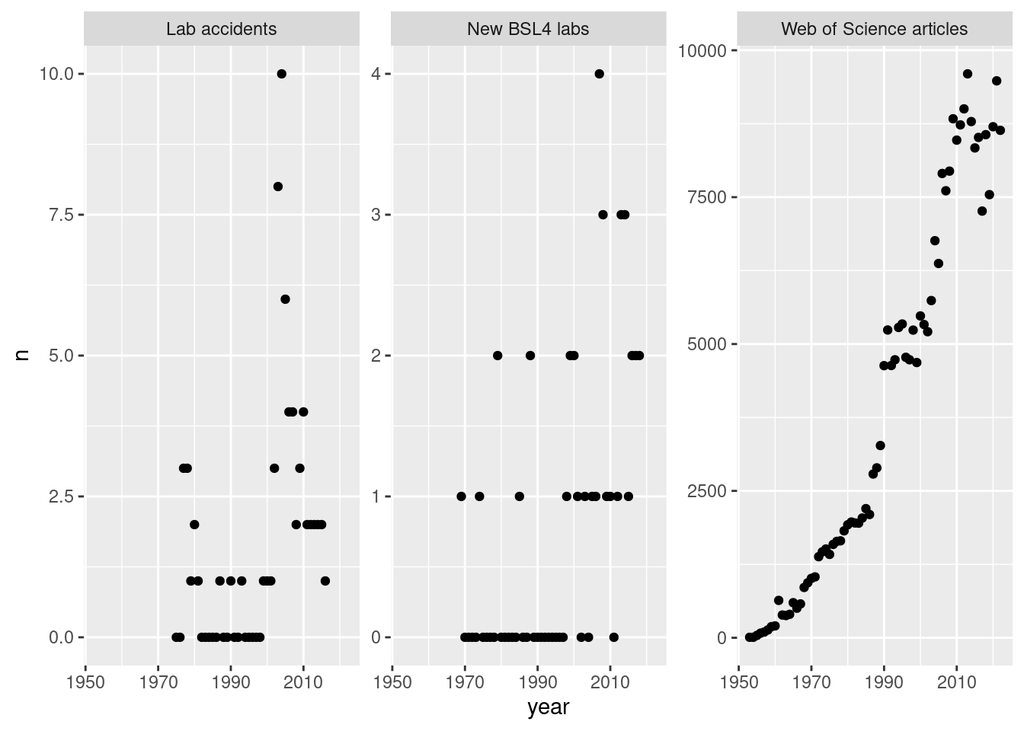

```r
all_counts |>
    ggplot(aes(year, n)) +
    geom_point() +
    facet_wrap(~type, scales = "free_y")
```

```r
break_fit = segmented(
    obj = MASS::glm.nb(
        n ~ year + type,
        data = all_counts
    ),
    seg.Z = ~year,
    psi = c(1990, 2010)
)
summary(break_fit)
```

```
##
##  ***Regression Model with Segmented Relationship(s)***
##
## Call:
## segmented.glm(obj = MASS::glm.nb(n ~ year + type, data = all_counts),
##     seg.Z = ~year, psi = c(1990, 2010))
##
## Estimated Break-Point(s):
##                Est. St.Err
## psi1.year 1961.050  0.342
## psi2.year 2006.899  1.461
##
## Meaningful coefficients of the linear terms:
##                               Estimate Std. Error t value Pr(>|t|)
## (Intercept)                 -9.375e+02  5.507e+01 -17.026  < 2e-16 ***
## year                         4.772e-01  2.813e-02  16.966  < 2e-16 ***
## typeNew BSL4 labs           -6.986e-01  1.798e-01  -3.884 0.000152 ***
## typeWeb of Science articles  8.035e+00  1.120e-01  71.750  < 2e-16 ***
## U1.year                     -4.150e-01  2.819e-02 -14.721       NA
## U2.year                     -7.063e-02  9.073e-03  -7.784       NA
## ---
## Signif. codes:  0 '***' 0.001 '**' 0.01 '*' 0.05 '.' 0.1 ' ' 1
##
## (Dispersion parameter for Negative Binomial(27.3953) family taken to be 0.7702472)
##
## Null     deviance: 24409.03  on 161  degrees of freedom
## Residual deviance:   105.42  on 154  degrees of freedom
## AIC: 1381.8
##
## Boot restarting based on 6 samples. Last fit:
## Convergence attained in 6 iterations (rel. change 2.6539e-07)
```

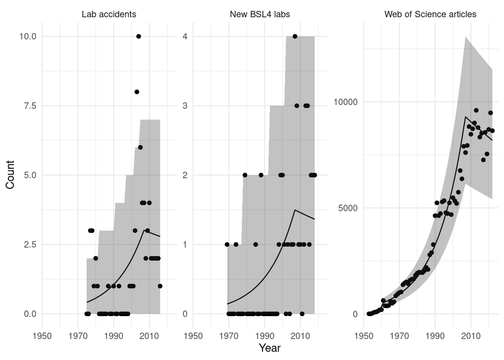

```r
augment(break_fit, newdata = all_counts, type.predict = "response") |>
    ggplot(aes(year, .fitted)) +
    geom_line() +
    geom_point(aes(year, n)) +
    geom_ribbon(
        aes(
            ymin = qnbinom(0.025, mu = .fitted, size = break_fit$theta),
            ymax = qnbinom(0.975, mu = .fitted, size = break_fit$theta),
        ),
        alpha = 0.3,
    ) +
    theme_minimal() +
    facet_wrap(~type, scales = "free_y") +
    labs(
        x = "Year",
        y = "Count"
    )
```